# Vessel Densities in the Belgian Part of the North Sea

Lennert Schepers

4/28/2020

## Vessel density in Belgium

In this small exercise we want to analyse vessel route densities in the Belgian part of the North Sea. The data for this exercise comes from [EMODnet Human activities](https://www.emodnet-humanactivities.eu/). EMODnet Human Activities has two types of vessel density data, one created by the Human Activities portal themselves, giving the vessel hours per square km per month by ship type. See [here](https://www.emodnet-humanactivities.eu/search-results.php?dataname=Vessel+Density+).

And one created by the European Maritime Safety Agency (EMSA), giving the number of routes per square km per month) by ship type. The advantage of the latter is that this provides recent information. For example, writing now 28th of April, the monthly aggregated data is already available for March 2020. For details, see [here](https://www.emodnet-humanactivities.eu/search-results.php?dataname=Route+density+%28source%3A+EMSA%29)

First, we load the R libraries that we will use

```r
## load rasters
library(raster)
library(sf)
library(mapview)
library(ggplot2)
library(data.table)
```

For this exercise, we are only interested in Belgian waters, so we’ll use bounding box of the Belgian Exclusive Economic ZOne:

```r
BCP <- st_read("http://geo.vliz.be/geoserver/MarineRegions/wfs?service=WFS&version=2.0.0&request=GetFeature&typeNames=eez&cql_filter=mrgid=%273293%27&outputFormat=application/json")
```

```r
BCP <- st_cast(BCP, "POLYGON")
BCP_bbox <- st_bbox(BCP$geometry)
mapview(BCP)
```

[interactive chart not shown]

Now, we create a function to retrieve the route density for a particular fishing type, month and year *in Belgian waters*

```r
base_url <- 'https://ows.emodnet-humanactivities.eu/wcs?SERVICE=WCS&VERSION=1.0.0&request=GetCapabilities'

# BACKGROUND INFO ON EMODNet Human Activities' WCS Service, and the 'route density maps'
    # The Open Geospatial Consortium (OGC) Web Coverage Service Interface Standard (WCS) defines Web-based retrieval of coverages – that is, digital geospatial information representing space/time-varying phenomena.
    #
    # Get Capabilities:
    #   https://ows.emodnet-humanactivities.eu/wcs?SERVICE=WCS&VERSION=1.0.0&request=GetCapabilities
    #
    # Get Coverage Example:
    #   https://ows.emodnet-humanactivities.eu/wcs?service=wcs&version=1.0.0&request=getcoverage&coverage=emodnet:2019_01_rd_All&crs=EPSG:4326&BBOX=15,20.5,30,32.5&format=image/tiff&interpolation=nearest&resx=0.00833333&resy=0.00833333
    #
    # The names of the web service layers are -
    #   '<year>_<month>_rd_<vessel code>' Eg. '2019_01_rd_All' for all vessels during January 2019
    # '<year>_<season>_rd_<vessel code>' Eg. '2019_spring_rd_All' for all vessels during Spring 2019
    # '<year>_yearly_rd_<vessel code>' Eg. '2019_yearly_rd_All' for the total of all vessels during 2019.
    # The vessel codes are as follows:
    #
    # All - All types
    # 01 - Cargo
    # 02 - Fishing
    # 03 - Passenger
    # 04 - Tanker
    # 05 - Other
    #
    #Available data: January 2019 - March 2020

# function to get belgian raster data, based on year, month, vessel_code
getBelgianCSW <- function(year, month, vessel_code){
  url <- paste0("https://ows.emodnet-humanactivities.eu/wcs?service=wcs&version=1.0.0&request=getcoverage&coverage=emodnet:",
                year, "_",
                formatC(month, width = 2, flag = 0), "_rd_",
                vessel_code, "&",
                "crs=EPSG:4326&BBOX=", paste(BCP_bbox, collapse = ","), "&",
                "format=image/tiff&",
                "interpolation=nearest&resx=0.00833333&resy=0.00833333"
  )
  raster(url)
}
```

Now we extract the Vessel density data from the WCS function, and store it in a rasterbrick:

```r
Cargo <- brick(x = c(getBelgianCSW(2019, 1, "01"),
                     getBelgianCSW(2019, 2, "01"),
                     getBelgianCSW(2019, 3, "01"),
                     getBelgianCSW(2019, 4, "01"),
                     getBelgianCSW(2019, 5, "01"),
                     getBelgianCSW(2019, 6, "01"),
                     getBelgianCSW(2019, 7, "01"),
                     getBelgianCSW(2019, 8, "01"),
                     getBelgianCSW(2019, 9, "01"),
                     getBelgianCSW(2019, 10, "01"),
                     getBelgianCSW(2019, 11, "01"),
                     getBelgianCSW(2019, 12, "01"),
                     getBelgianCSW(2020, 1, "01"),
                     getBelgianCSW(2020, 2, "01"),
                     getBelgianCSW(2020, 3, "01")
                                   )
)


Fishing <- brick(x = c(getBelgianCSW(2019, 1, "02"),
                     getBelgianCSW(2019, 2, "02"),
                     getBelgianCSW(2019, 3, "02"),
                     getBelgianCSW(2019, 4, "02"),
                     getBelgianCSW(2019, 5, "02"),
                     getBelgianCSW(2019, 6, "02"),
                     getBelgianCSW(2019, 7, "02"),
                     getBelgianCSW(2019, 8, "02"),
                     getBelgianCSW(2019, 9, "02"),
                     getBelgianCSW(2019, 10, "02"),
                     getBelgianCSW(2019, 11, "02"),
                     getBelgianCSW(2019, 12, "02"),
                     getBelgianCSW(2020, 1, "02"),
                     getBelgianCSW(2020, 2, "02"),
                     getBelgianCSW(2020, 3, "02")
                     )
)

mapview(Fishing[[1]]) + mapview(BCP, alpha.regions = 0.1)
```

[interactive chart not shown]

```r
Passenger <- brick(x = c(getBelgianCSW(2019, 1, "03"),
                       getBelgianCSW(2019, 2, "03"),
                       getBelgianCSW(2019, 3, "03"),
                       getBelgianCSW(2019, 4, "03"),
                       getBelgianCSW(2019, 5, "03"),
                       getBelgianCSW(2019, 6, "03"),
                       getBelgianCSW(2019, 7, "03"),
                       getBelgianCSW(2019, 8, "03"),
                       getBelgianCSW(2019, 9, "03"),
                       getBelgianCSW(2019, 10, "03"),
                       getBelgianCSW(2019, 11, "03"),
                       getBelgianCSW(2019, 12, "03"),
                       getBelgianCSW(2020, 1, "03"),
                       getBelgianCSW(2020, 2, "03"),
                       getBelgianCSW(2020, 3, "03")
)
)

Tanker <- brick(x = c(getBelgianCSW(2019, 1, "04"),
                         getBelgianCSW(2019, 2, "04"),
                         getBelgianCSW(2019, 3, "04"),
                         getBelgianCSW(2019, 4, "04"),
                         getBelgianCSW(2019, 5, "04"),
                         getBelgianCSW(2019, 6, "04"),
                         getBelgianCSW(2019, 7, "04"),
                         getBelgianCSW(2019, 8, "04"),
                         getBelgianCSW(2019, 9, "04"),
                         getBelgianCSW(2019, 10, "04"),
                         getBelgianCSW(2019, 11, "04"),
                         getBelgianCSW(2019, 12, "04"),
                         getBelgianCSW(2020, 1, "04"),
                         getBelgianCSW(2020, 2, "04"),
                         getBelgianCSW(2020, 3, "04")
)
)

Other <- brick(x = c(getBelgianCSW(2019, 1, "05"),
                      getBelgianCSW(2019, 2, "05"),
                      getBelgianCSW(2019, 3, "05"),
                      getBelgianCSW(2019, 4, "05"),
                      getBelgianCSW(2019, 5, "05"),
                      getBelgianCSW(2019, 6, "05"),
                      getBelgianCSW(2019, 7, "05"),
                      getBelgianCSW(2019, 8, "05"),
                      getBelgianCSW(2019, 9, "05"),
                      getBelgianCSW(2019, 10, "05"),
                      getBelgianCSW(2019, 11, "05"),
                      getBelgianCSW(2019, 12, "05"),
                      getBelgianCSW(2020, 1, "05"),
                      getBelgianCSW(2020, 2, "05"),
                      getBelgianCSW(2020, 3, "05")
)
)

All <- brick(x = c('All-2019-01' = getBelgianCSW(2019, 1, "All"),
                   'All-2019-02' = getBelgianCSW(2019, 2, "All"),
                   'All-2019-03' = getBelgianCSW(2019, 3, "All"),
                   'All-2019-04' = getBelgianCSW(2019, 4, "All"),
                   'All-2019-05' = getBelgianCSW(2019, 5, "All"),
                   'All-2019-06' = getBelgianCSW(2019, 6, "All"),
                   'All-2019-07' = getBelgianCSW(2019, 7, "All"),
                   'All-2019-08' = getBelgianCSW(2019, 8, "All"),
                   'All-2019-09' = getBelgianCSW(2019, 9, "All"),
                   'All-2019-10' = getBelgianCSW(2019, 10, "All"),
                   'All-2019-11' = getBelgianCSW(2019, 11, "All"),
                   'All-2019-12' = getBelgianCSW(2019, 12, "All"),
                   'All-2020-01' = getBelgianCSW(2020, 1, "All"),
                   'All-2020-02' = getBelgianCSW(2020, 2, "All"),
                   'All-2020-03' = getBelgianCSW(2020, 3, "All")
)
)
```

No we create a data frame to store the statistics that we will extract from the rasters. We extract for all values of the Belgian EEZ, the average value of all raster cells.

```r
# create data frame, with 1st column 'time'
  df.sr <- data.frame(Date = seq(as.Date("2019/1/1"), by = "month", length.out = 15))

  # extract all values from the rasters, by the BCP polygon, and average the values.
  df.sr$Cargo     <- as.vector(extract(Cargo, BCP, fun = mean))
  df.sr$Fishing   <- as.vector(extract(Fishing, BCP, fun = mean))
  df.sr$Passenger <- as.vector(extract(Passenger, BCP, fun = mean))
  df.sr$Tanker    <- as.vector(extract(Tanker, BCP, fun = mean))
  df.sr$Other     <- as.vector(extract(Other, BCP, fun = mean))
  df.sr$All       <- as.vector(extract(All, BCP, fun = mean))

# transform to long format:
  df.sr.long <- melt.data.table(as.data.table(df.sr),
                                id.vars = "Date")
```

A plot of the result:

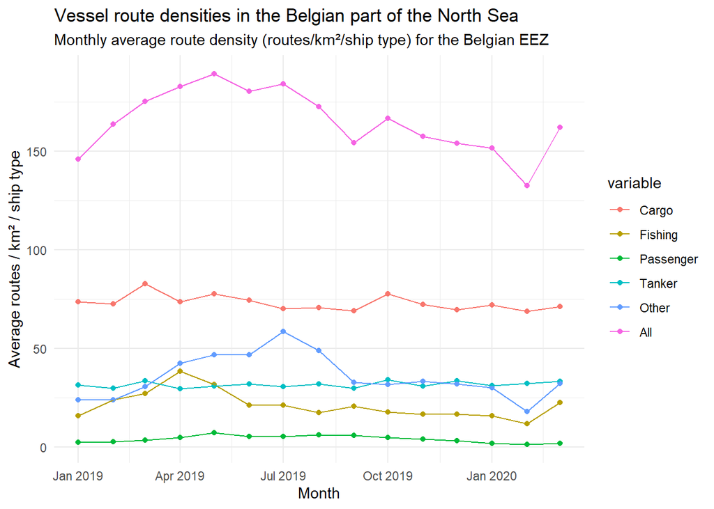

```r
ggplot(df.sr.long, aes(x = Date, y = value, group = variable)) +
  geom_point(aes(color = variable)) +
  geom_line(aes(color = variable)) +
  labs(title = "Vessel route densities in the Belgian part of the North Sea",
       subtitle = "Monthly average route density (routes/km²/ship type) for the Belgian EEZ",
       x = "Month",
       y = "Average routes / km² / ship type") +
  theme_minimal()
```